# Risk Factor Analysis

## Outcome Variable

**Outcome Variable:** ever_co

## Predictor Variables

**Intervention Variable:** fhtcm

**Adjustment Set:**

unadjusted

## Stratifying Variables

The analysis was stratified on these variable(s):

- agecat
- studyid
- country

## Data Summary

| agecat | studyid | country | fhtcm | ever_co | n_cell | n | outcome_variable |
| --- | --- | --- | --- | --- | --- | --- | --- |
| 0-24 months | ki1000304b-SAS-CompFeed | INDIA | >=167 cm | 0 | 327 | 895 | ever_co |
| 0-24 months | ki1000304b-SAS-CompFeed | INDIA | >=167 cm | 1 | 80 | 895 | ever_co |
| 0-24 months | ki1000304b-SAS-CompFeed | INDIA | <162 cm | 0 | 162 | 895 | ever_co |
| 0-24 months | ki1000304b-SAS-CompFeed | INDIA | <162 cm | 1 | 64 | 895 | ever_co |
| 0-24 months | ki1000304b-SAS-CompFeed | INDIA | [162-167) cm | 0 | 196 | 895 | ever_co |
| 0-24 months | ki1000304b-SAS-CompFeed | INDIA | [162-167) cm | 1 | 66 | 895 | ever_co |
| 0-24 months | ki1000304b-SAS-FoodSuppl | INDIA | >=167 cm | 0 | 73 | 399 | ever_co |
| 0-24 months | ki1000304b-SAS-FoodSuppl | INDIA | >=167 cm | 1 | 33 | 399 | ever_co |
| 0-24 months | ki1000304b-SAS-FoodSuppl | INDIA | <162 cm | 0 | 84 | 399 | ever_co |
| 0-24 months | ki1000304b-SAS-FoodSuppl | INDIA | <162 cm | 1 | 79 | 399 | ever_co |
| 0-24 months | ki1000304b-SAS-FoodSuppl | INDIA | [162-167) cm | 0 | 91 | 399 | ever_co |
| 0-24 months | ki1000304b-SAS-FoodSuppl | INDIA | [162-167) cm | 1 | 39 | 399 | ever_co |
| 0-24 months | ki1101329-Keneba | GAMBIA | >=167 cm | 0 | 1062 | 1929 | ever_co |
| 0-24 months | ki1101329-Keneba | GAMBIA | >=167 cm | 1 | 183 | 1929 | ever_co |
| 0-24 months | ki1101329-Keneba | GAMBIA | <162 cm | 0 | 111 | 1929 | ever_co |
| 0-24 months | ki1101329-Keneba | GAMBIA | <162 cm | 1 | 21 | 1929 | ever_co |
| 0-24 months | ki1101329-Keneba | GAMBIA | [162-167) cm | 0 | 444 | 1929 | ever_co |
| 0-24 months | ki1101329-Keneba | GAMBIA | [162-167) cm | 1 | 108 | 1929 | ever_co |
| 0-24 months | ki1119695-PROBIT | BELARUS | >=167 cm | 0 | 11722 | 12537 | ever_co |
| 0-24 months | ki1119695-PROBIT | BELARUS | >=167 cm | 1 | 22 | 12537 | ever_co |
| 0-24 months | ki1119695-PROBIT | BELARUS | <162 cm | 0 | 168 | 12537 | ever_co |
| 0-24 months | ki1119695-PROBIT | BELARUS | <162 cm | 1 | 0 | 12537 | ever_co |
| 0-24 months | ki1119695-PROBIT | BELARUS | [162-167) cm | 0 | 624 | 12537 | ever_co |
| 0-24 months | ki1119695-PROBIT | BELARUS | [162-167) cm | 1 | 1 | 12537 | ever_co |
| 0-24 months | ki1135781-COHORTS | GUATEMALA | >=167 cm | 0 | 59 | 495 | ever_co |
| 0-24 months | ki1135781-COHORTS | GUATEMALA | >=167 cm | 1 | 4 | 495 | ever_co |
| 0-24 months | ki1135781-COHORTS | GUATEMALA | <162 cm | 0 | 244 | 495 | ever_co |
| 0-24 months | ki1135781-COHORTS | GUATEMALA | <162 cm | 1 | 49 | 495 | ever_co |
| 0-24 months | ki1135781-COHORTS | GUATEMALA | [162-167) cm | 0 | 119 | 495 | ever_co |
| 0-24 months | ki1135781-COHORTS | GUATEMALA | [162-167) cm | 1 | 20 | 495 | ever_co |

[output cut: 60 more lines]

The following strata were considered:

- agecat: 0-24 months, studyid: ki1000304b-SAS-CompFeed, country: INDIA
- agecat: 0-24 months, studyid: ki1000304b-SAS-FoodSuppl, country: INDIA
- agecat: 0-24 months, studyid: ki1101329-Keneba, country: GAMBIA
- agecat: 0-24 months, studyid: ki1119695-PROBIT, country: BELARUS
- agecat: 0-24 months, studyid: ki1135781-COHORTS, country: GUATEMALA
- agecat: 0-6 months, studyid: ki1000304b-SAS-CompFeed, country: INDIA
- agecat: 0-6 months, studyid: ki1000304b-SAS-FoodSuppl, country: INDIA
- agecat: 0-6 months, studyid: ki1101329-Keneba, country: GAMBIA
- agecat: 0-6 months, studyid: ki1119695-PROBIT, country: BELARUS
- agecat: 0-6 months, studyid: ki1135781-COHORTS, country: GUATEMALA
- agecat: 6-24 months, studyid: ki1000304b-SAS-CompFeed, country: INDIA
- agecat: 6-24 months, studyid: ki1000304b-SAS-FoodSuppl, country: INDIA
- agecat: 6-24 months, studyid: ki1101329-Keneba, country: GAMBIA
- agecat: 6-24 months, studyid: ki1119695-PROBIT, country: BELARUS
- agecat: 6-24 months, studyid: ki1135781-COHORTS, country: GUATEMALA

### Dropped Strata

Some strata were dropped due to rare outcomes:

- agecat: 0-24 months, studyid: ki1119695-PROBIT, country: BELARUS
- agecat: 0-24 months, studyid: ki1135781-COHORTS, country: GUATEMALA
- agecat: 0-6 months, studyid: ki1101329-Keneba, country: GAMBIA
- agecat: 0-6 months, studyid: ki1119695-PROBIT, country: BELARUS
- agecat: 0-6 months, studyid: ki1135781-COHORTS, country: GUATEMALA
- agecat: 6-24 months, studyid: ki1119695-PROBIT, country: BELARUS
- agecat: 6-24 months, studyid: ki1135781-COHORTS, country: GUATEMALA

## Methods Detail

We’re interested in the causal parameters $E[Y_a]$ for all values of $a \in \mathcal{A}$. These parameters represent the mean outcome if, possibly contrary to fact, we intervened to set all units to have $A=a$. Under the randomization and positivity assumptions, these are identified by the statistical parameters $\psi_a=E_W[E_{Y|A,W}(Y|A=a,W)]$. In addition, we’re interested in the mean of $Y$, $E[Y]$ under no intervention (the observed mean). We will estimate these parameters by using SuperLearner to fit the relevant likelihood factors – $E_{Y|A,W}(Y|A=a,W)$ and $p(A=a|W)$, and then updating our likelihood fit using a joint TMLE.

For unadjusted analyses ($W=\{\}$), initial likelihoods were estimated using Lrnr_glm to estimate the simple $E(Y|A)$ and Lrnr_mean to estimate $p(A)$. For adjusted analyses, a small library containing Lrnr_glmnet, Lrnr_xgboost, and Lrnr_mean was used.

Having estimated these parameters, we will then use the delta method to estimate relative risks and attributable risks relative to a prespecified baseline level of $A$.

# Results Detail

## Results Plots

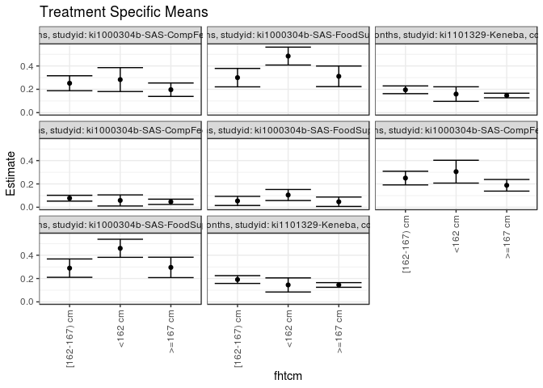

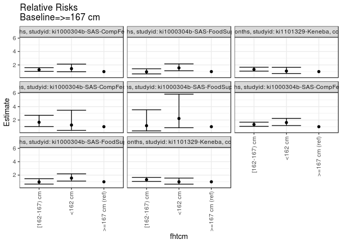

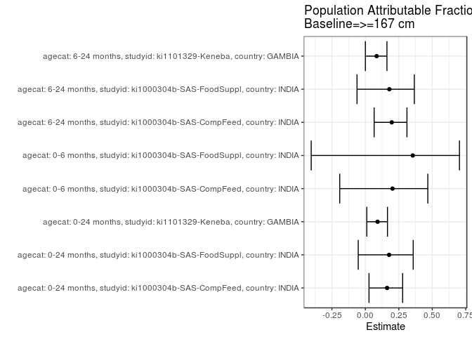

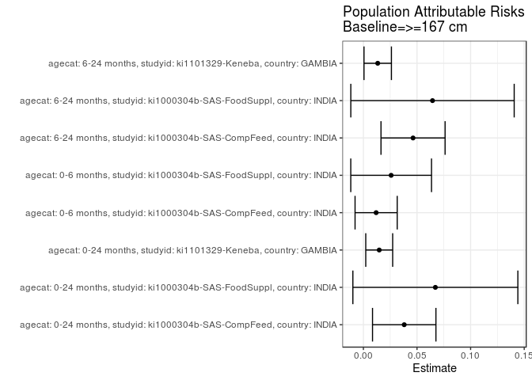

## Results Table

### Parameter: TSM

| agecat | studyid | country | intervention_level | baseline_level | estimate | ci_lower | ci_upper |
| --- | --- | --- | --- | --- | --- | --- | --- |
| 0-24 months | ki1000304b-SAS-CompFeed | INDIA | >=167 cm | NA | 0.1965602 | 0.1389987 | 0.2541217 |
| 0-24 months | ki1000304b-SAS-CompFeed | INDIA | <162 cm | NA | 0.2831858 | 0.1808723 | 0.3854994 |
| 0-24 months | ki1000304b-SAS-CompFeed | INDIA | [162-167) cm | NA | 0.2519084 | 0.1878339 | 0.3159829 |
| 0-24 months | ki1000304b-SAS-FoodSuppl | INDIA | >=167 cm | NA | 0.3113208 | 0.2230631 | 0.3995785 |
| 0-24 months | ki1000304b-SAS-FoodSuppl | INDIA | <162 cm | NA | 0.4846626 | 0.4078443 | 0.5614809 |
| 0-24 months | ki1000304b-SAS-FoodSuppl | INDIA | [162-167) cm | NA | 0.3000000 | 0.2211265 | 0.3788735 |
| 0-24 months | ki1101329-Keneba | GAMBIA | >=167 cm | NA | 0.1469880 | 0.1273139 | 0.1666620 |
| 0-24 months | ki1101329-Keneba | GAMBIA | <162 cm | NA | 0.1590909 | 0.0966785 | 0.2215033 |
| 0-24 months | ki1101329-Keneba | GAMBIA | [162-167) cm | NA | 0.1956522 | 0.1625501 | 0.2287543 |
| 0-6 months | ki1000304b-SAS-CompFeed | INDIA | >=167 cm | NA | 0.0466830 | 0.0241262 | 0.0692399 |
| 0-6 months | ki1000304b-SAS-CompFeed | INDIA | <162 cm | NA | 0.0582960 | 0.0107864 | 0.1058055 |
| 0-6 months | ki1000304b-SAS-CompFeed | INDIA | [162-167) cm | NA | 0.0775194 | 0.0525923 | 0.1024464 |
| 0-6 months | ki1000304b-SAS-FoodSuppl | INDIA | >=167 cm | NA | 0.0471698 | 0.0067604 | 0.0875792 |
| 0-6 months | ki1000304b-SAS-FoodSuppl | INDIA | <162 cm | NA | 0.1049383 | 0.0576850 | 0.1521915 |
| 0-6 months | ki1000304b-SAS-FoodSuppl | INDIA | [162-167) cm | NA | 0.0542636 | 0.0151218 | 0.0934053 |
| 6-24 months | ki1000304b-SAS-CompFeed | INDIA | >=167 cm | NA | 0.1881443 | 0.1382118 | 0.2380768 |
| 6-24 months | ki1000304b-SAS-CompFeed | INDIA | <162 cm | NA | 0.3050000 | 0.2072026 | 0.4027974 |
| 6-24 months | ki1000304b-SAS-CompFeed | INDIA | [162-167) cm | NA | 0.2500000 | 0.1914997 | 0.3085003 |
| 6-24 months | ki1000304b-SAS-FoodSuppl | INDIA | >=167 cm | NA | 0.2952381 | 0.2078775 | 0.3825987 |
| 6-24 months | ki1000304b-SAS-FoodSuppl | INDIA | <162 cm | NA | 0.4591195 | 0.3815631 | 0.5366759 |
| 6-24 months | ki1000304b-SAS-FoodSuppl | INDIA | [162-167) cm | NA | 0.2890625 | 0.2104287 | 0.3676963 |
| 6-24 months | ki1101329-Keneba | GAMBIA | >=167 cm | NA | 0.1450253 | 0.1249796 | 0.1650710 |
| 6-24 months | ki1101329-Keneba | GAMBIA | <162 cm | NA | 0.1450382 | 0.0847205 | 0.2053558 |
| 6-24 months | ki1101329-Keneba | GAMBIA | [162-167) cm | NA | 0.1913696 | 0.1579645 | 0.2247748 |

### Parameter: E(Y)

| agecat | studyid | country | intervention_level | baseline_level | estimate | ci_lower | ci_upper |
| --- | --- | --- | --- | --- | --- | --- | --- |
| 0-24 months | ki1000304b-SAS-CompFeed | INDIA | NA | NA | 0.2346369 | 0.1798928 | 0.2893809 |
| 0-24 months | ki1000304b-SAS-FoodSuppl | INDIA | NA | NA | 0.3784461 | 0.3307978 | 0.4260945 |
| 0-24 months | ki1101329-Keneba | GAMBIA | NA | NA | 0.1617418 | 0.1453059 | 0.1781778 |
| 0-6 months | ki1000304b-SAS-CompFeed | INDIA | NA | NA | 0.0585586 | 0.0394255 | 0.0776916 |
| 0-6 months | ki1000304b-SAS-FoodSuppl | INDIA | NA | NA | 0.0730479 | 0.0474188 | 0.0986769 |
| 6-24 months | ki1000304b-SAS-CompFeed | INDIA | NA | NA | 0.2344498 | 0.1848813 | 0.2840182 |
| 6-24 months | ki1000304b-SAS-FoodSuppl | INDIA | NA | NA | 0.3596939 | 0.3121253 | 0.4072624 |
| 6-24 months | ki1101329-Keneba | GAMBIA | NA | NA | 0.1583784 | 0.1417371 | 0.1750196 |

### Parameter: RR

| agecat | studyid | country | intervention_level | baseline_level | estimate | ci_lower | ci_upper |
| --- | --- | --- | --- | --- | --- | --- | --- |
| 0-24 months | ki1000304b-SAS-CompFeed | INDIA | >=167 cm | >=167 cm | 1.0000000 | 1.0000000 | 1.000000 |
| 0-24 months | ki1000304b-SAS-CompFeed | INDIA | <162 cm | >=167 cm | 1.4407080 | 0.9796518 | 2.118752 |
| 0-24 months | ki1000304b-SAS-CompFeed | INDIA | [162-167) cm | >=167 cm | 1.2815840 | 1.0336346 | 1.589012 |
| 0-24 months | ki1000304b-SAS-FoodSuppl | INDIA | >=167 cm | >=167 cm | 1.0000000 | 1.0000000 | 1.000000 |
| 0-24 months | ki1000304b-SAS-FoodSuppl | INDIA | <162 cm | >=167 cm | 1.5567949 | 1.1250591 | 2.154207 |
| 0-24 months | ki1000304b-SAS-FoodSuppl | INDIA | [162-167) cm | >=167 cm | 0.9636364 | 0.6546316 | 1.418500 |
| 0-24 months | ki1101329-Keneba | GAMBIA | >=167 cm | >=167 cm | 1.0000000 | 1.0000000 | 1.000000 |
| 0-24 months | ki1101329-Keneba | GAMBIA | <162 cm | >=167 cm | 1.0823398 | 0.7150618 | 1.638263 |
| 0-24 months | ki1101329-Keneba | GAMBIA | [162-167) cm | >=167 cm | 1.3310763 | 1.0727831 | 1.651558 |
| 0-6 months | ki1000304b-SAS-CompFeed | INDIA | >=167 cm | >=167 cm | 1.0000000 | 1.0000000 | 1.000000 |
| 0-6 months | ki1000304b-SAS-CompFeed | INDIA | <162 cm | >=167 cm | 1.2487609 | 0.4505789 | 3.460889 |
| 0-6 months | ki1000304b-SAS-CompFeed | INDIA | [162-167) cm | >=167 cm | 1.6605467 | 1.0196793 | 2.704199 |
| 0-6 months | ki1000304b-SAS-FoodSuppl | INDIA | >=167 cm | >=167 cm | 1.0000000 | 1.0000000 | 1.000000 |
| 0-6 months | ki1000304b-SAS-FoodSuppl | INDIA | <162 cm | >=167 cm | 2.2246913 | 0.8451872 | 5.855805 |
| 0-6 months | ki1000304b-SAS-FoodSuppl | INDIA | [162-167) cm | >=167 cm | 1.1503876 | 0.3753798 | 3.525474 |
| 6-24 months | ki1000304b-SAS-CompFeed | INDIA | >=167 cm | >=167 cm | 1.0000000 | 1.0000000 | 1.000000 |
| 6-24 months | ki1000304b-SAS-CompFeed | INDIA | <162 cm | >=167 cm | 1.6210959 | 1.1739324 | 2.238589 |
| 6-24 months | ki1000304b-SAS-CompFeed | INDIA | [162-167) cm | >=167 cm | 1.3287671 | 1.0542466 | 1.674771 |
| 6-24 months | ki1000304b-SAS-FoodSuppl | INDIA | >=167 cm | >=167 cm | 1.0000000 | 1.0000000 | 1.000000 |
| 6-24 months | ki1000304b-SAS-FoodSuppl | INDIA | <162 cm | >=167 cm | 1.5550822 | 1.1060625 | 2.186387 |
| 6-24 months | ki1000304b-SAS-FoodSuppl | INDIA | [162-167) cm | >=167 cm | 0.9790827 | 0.6550260 | 1.463458 |
| 6-24 months | ki1101329-Keneba | GAMBIA | >=167 cm | >=167 cm | 1.0000000 | 1.0000000 | 1.000000 |
| 6-24 months | ki1101329-Keneba | GAMBIA | <162 cm | >=167 cm | 1.0000888 | 0.6452263 | 1.550119 |
| 6-24 months | ki1101329-Keneba | GAMBIA | [162-167) cm | >=167 cm | 1.3195602 | 1.0561623 | 1.648647 |

### Parameter: PAR

| agecat | studyid | country | intervention_level | baseline_level | estimate | ci_lower | ci_upper |
| --- | --- | --- | --- | --- | --- | --- | --- |
| 0-24 months | ki1000304b-SAS-CompFeed | INDIA | >=167 cm | NA | 0.0380767 | 0.0085036 | 0.0676498 |
| 0-24 months | ki1000304b-SAS-FoodSuppl | INDIA | >=167 cm | NA | 0.0671254 | -0.0098230 | 0.1440737 |
| 0-24 months | ki1101329-Keneba | GAMBIA | >=167 cm | NA | 0.0147539 | 0.0022012 | 0.0273066 |
| 0-6 months | ki1000304b-SAS-CompFeed | INDIA | >=167 cm | NA | 0.0118755 | -0.0077820 | 0.0315330 |
| 0-6 months | ki1000304b-SAS-FoodSuppl | INDIA | >=167 cm | NA | 0.0258780 | -0.0117754 | 0.0635315 |
| 6-24 months | ki1000304b-SAS-CompFeed | INDIA | >=167 cm | NA | 0.0463054 | 0.0164114 | 0.0761994 |
| 6-24 months | ki1000304b-SAS-FoodSuppl | INDIA | >=167 cm | NA | 0.0644558 | -0.0117422 | 0.1406538 |
| 6-24 months | ki1101329-Keneba | GAMBIA | >=167 cm | NA | 0.0133531 | 0.0005644 | 0.0261417 |

### Parameter: PAF

| agecat | studyid | country | intervention_level | baseline_level | estimate | ci_lower | ci_upper |
| --- | --- | --- | --- | --- | --- | --- | --- |
| 0-24 months | ki1000304b-SAS-CompFeed | INDIA | >=167 cm | NA | 0.1622792 | 0.0272450 | 0.2785684 |
| 0-24 months | ki1000304b-SAS-FoodSuppl | INDIA | >=167 cm | NA | 0.1773710 | -0.0532915 | 0.3575202 |
| 0-24 months | ki1101329-Keneba | GAMBIA | >=167 cm | NA | 0.0912187 | 0.0105910 | 0.1652760 |
| 0-6 months | ki1000304b-SAS-CompFeed | INDIA | >=167 cm | NA | 0.2027972 | -0.1915794 | 0.4666471 |
| 0-6 months | ki1000304b-SAS-FoodSuppl | INDIA | >=167 cm | NA | 0.3542615 | -0.4046217 | 0.7031385 |
| 6-24 months | ki1000304b-SAS-CompFeed | INDIA | >=167 cm | NA | 0.1975068 | 0.0655692 | 0.3108155 |
| 6-24 months | ki1000304b-SAS-FoodSuppl | INDIA | >=167 cm | NA | 0.1791962 | -0.0623603 | 0.3658283 |
| 6-24 months | ki1101329-Keneba | GAMBIA | >=167 cm | NA | 0.0843113 | 0.0002450 | 0.1613087 |